# Clase 3b - Visualización de resultados

La opción `limits = c(0, 2000000)` indica que los límites del eje *x* e *y* serán de 0 a 2000000. También podemos modificar los puntos de corte, pero en este caso no hará falta.

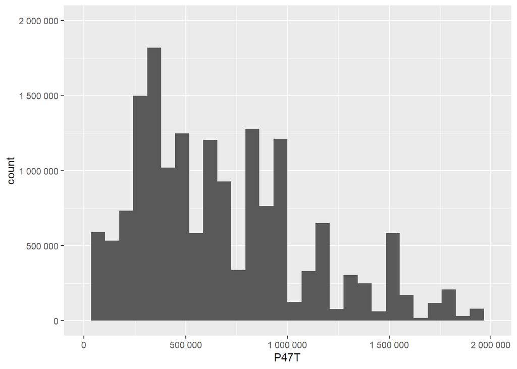

```r
ggplot(data = eph_ind, aes(x = P47T, weights = PONDII)) +
  geom_histogram() +
  scale_x_continuous(labels = label_number(), limits = c(0,2000000)) +
  scale_y_continuous(labels = label_number(), limits = c(0,2000000))
```

Dentro de la capa de geometría, podemos agregar argumentos que nos permitan personalizar el gráfico. Por ejemplo, cambiemos el color de las barras mediante la opción `fill` y el tamaño mediante la función `binwidth`. Pueden explorar las distintas formas de identificar las colores en este [sitio](https://r-graph-gallery.com/ggplot2-color.html).

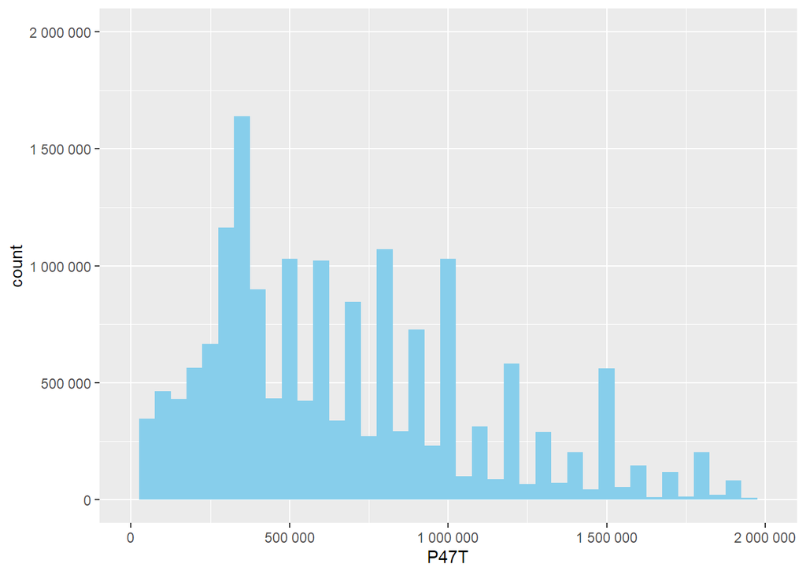

```r
ggplot(data = eph_ind, aes(x = P47T, weight = PONDII)) +
  geom_histogram(fill = "skyblue", binwidth = 50000) +
  scale_x_continuous(labels = label_number(), limits = c(0,2000000)) +
  scale_y_continuous(labels = label_number(), limits = c(0,2000000))
```

Ahora bien, para cerrar nuestro primer gráfico, vamos a agregarle un título y etiquetas a los ejes. Para ello, utilizaremos la función `labs()`. A su vez, podemos también modificar el tema visual del gráfico mediante la función `theme()`. Seleccionaremos el tema *minimal* mediante la capa `theme_minimal()`.

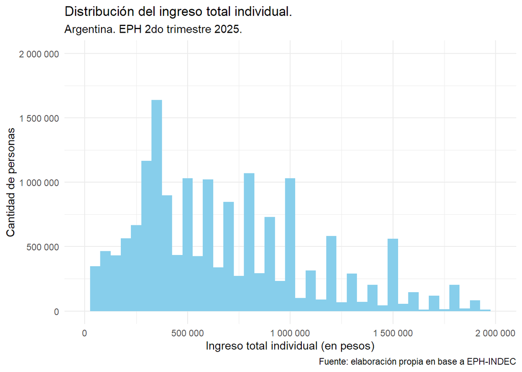

```r
ggplot(data = eph_ind, aes(x = P47T, weight = PONDII)) +
  geom_histogram(fill = "skyblue", binwidth = 50000) +
  scale_x_continuous(labels = label_number(), limits = c(0,2000000)) +
  scale_y_continuous(labels = label_number(), limits = c(0,2000000)) +
  labs(title = "Distribución del ingreso total individual.",
       subtitle = "Argentina. EPH 2do trimestre 2025.",
       caption = "Fuente: elaboración propia en base a EPH-INDEC",
       x = "Ingreso total individual (en pesos)",
       y = "Cantidad de personas") +
  theme_minimal()
```

Si queremos exportar el gráfico a un archivo, para luego utilizarlo en algún documento o compartirlo, podemos hacerlo mediante la función `ggsave()`. Esta función nos permite guardar el gráfico en distintos formatos, como `pdf`, `png`, `jpeg`, `tiff`, entre otros.

```r
ggsave("resultados/grafico_ingresos.jpeg", width = 8, height = 5, dpi = 300)
```

### 1.3.1 Observando diferencias por grupos

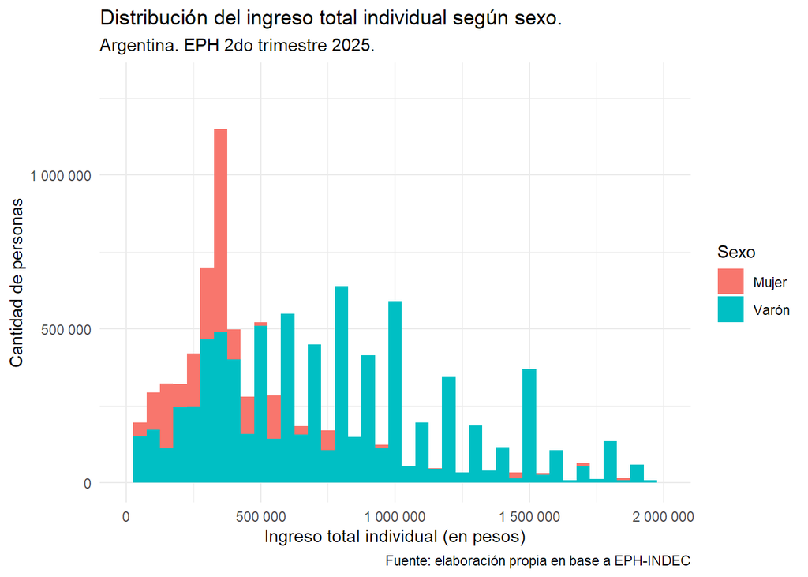

```r
ggplot(data = eph_ind, aes(x = P47T, weight = PONDII, fill = sexo)) +
  geom_histogram(binwidth = 50000, position = "identity") +
  scale_x_continuous(labels = label_number(), limits = c(0,2000000)) +
  scale_y_continuous(labels = label_number(), limits = c(0,1300000)) +
  labs(title = "Distribución del ingreso total individual según sexo.",
       subtitle = "Argentina. EPH 2do trimestre 2025.",
       caption = "Fuente: elaboración propia en base a EPH-INDEC",
       x = "Ingreso total individual (en pesos)",
       y = "Cantidad de personas",
       fill = "Sexo") +
  theme_minimal()
```

Podríamos mejorar la gráfica retocando la transparencia de las barras mediante la opción *alpha* en `geom_histogram`.

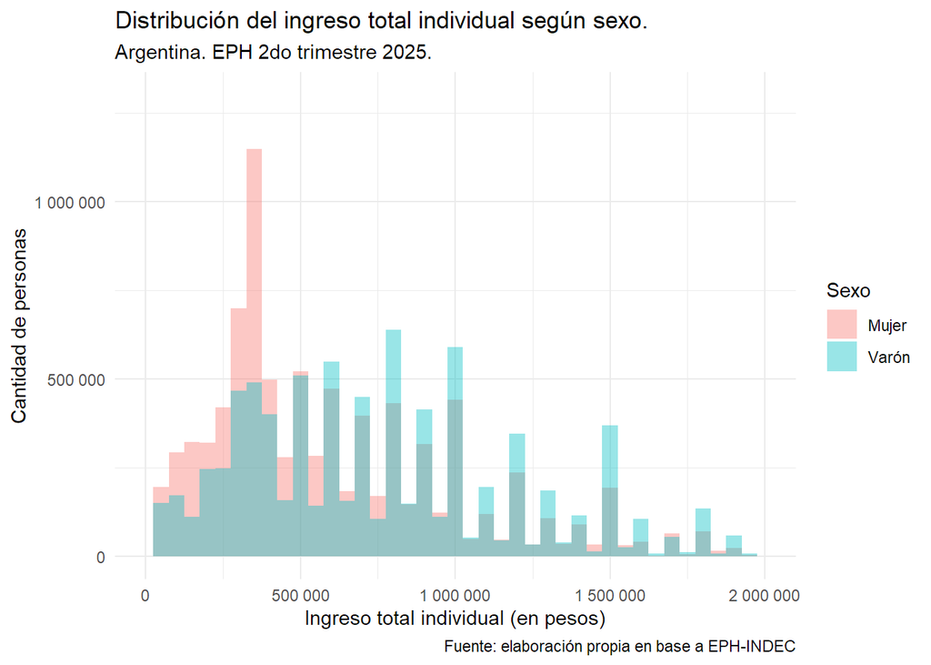

```r
ggplot(data = eph_ind, aes(x = P47T, weight = PONDII, fill = sexo)) +
  geom_histogram(binwidth = 50000, position = "identity", alpha = 0.4) +
  scale_x_continuous(labels = label_number(), limits = c(0,2000000)) +
  scale_y_continuous(labels = label_number(), limits = c(0,1300000)) +
  labs(title = "Distribución del ingreso total individual según sexo.",
       subtitle = "Argentina. EPH 2do trimestre 2025.",
       caption = "Fuente: elaboración propia en base a EPH-INDEC",
       x = "Ingreso total individual (en pesos)",
       y = "Cantidad de personas",
       fill = "Sexo") +
  theme_minimal()
```

Otra forma de evaluar las diferenciaciones por grupos es mediante *facetados*. Vamos a ver cómo hacer para que el gráfico se divida en dos paneles, uno para cada sexo. Para ello, vamos a utilizar la función `facet_wrap()` y le pasaremos como argumento la variable `sexo`.

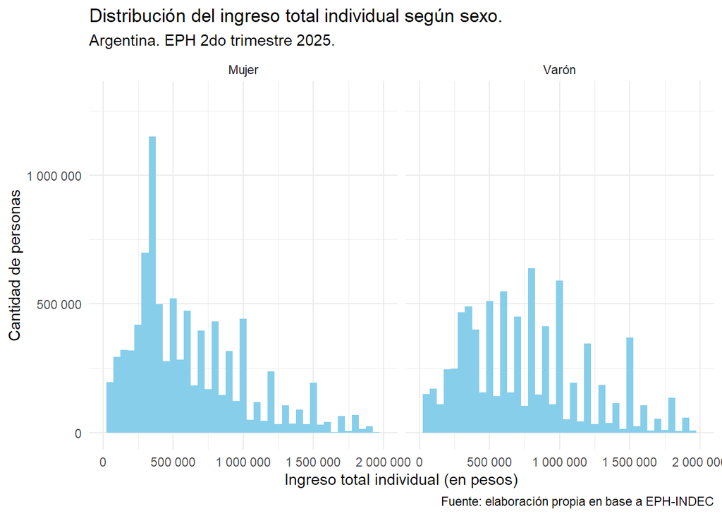

```r
ggplot(data = eph_ind, aes(x = P47T, weight = PONDII)) +
  geom_histogram(binwidth = 50000, fill = "skyblue") +
  scale_x_continuous(labels = label_number(), limits = c(0,2000000)) +
  scale_y_continuous(labels = label_number(), limits = c(0,1300000)) +
  labs(title = "Distribución del ingreso total individual según sexo.",
       subtitle = "Argentina. EPH 2do trimestre 2025.",
       caption = "Fuente: elaboración propia en base a EPH-INDEC",
       x = "Ingreso total individual (en pesos)",
       y = "Cantidad de personas") +
  theme_minimal() +
  facet_wrap(~sexo)
```

## 1.4 Gráficos de barras

Uno de los gráficos más utilizados en ciencias sociales para observar la distribución de las variables categóricas son los gráficos de barras. Por ejemplo, vamos a representar la proporción de hogares que realizaron distintos tipos de gastos especiales como estrategia de reproducción. Utilizaremos solo los casos correspondientes al 2do trimestre de 2025.

Como vamos a querer que los valores del eje y se presenten en porcentajes, primero vamos a calcular la proporción de personas en cada categoría. Para ello, utilizaremos la función `summarise` de `dplyr`. Asignaremos la nueva tabla agregada al objeto **gastos**. Como queremos obtener los valores ponderados vamos a dividir al **ponderador** cuando el gasto sea igual a 1 sobre la suma total. Esto nos dara una proporción como resultado.

```r
gastos <- eph_hog %>%
  filter(TRIMESTRE == 2, ANO4 == 2025) %>%
  summarise(ahorros = sum(PONDERA[ahorros == 1], na.rm = T) / sum(PONDERA, na.rm = T),
            prestamo_familiar = sum(PONDERA[prestamo_familiar == 1], na.rm = T) / sum(PONDERA, na.rm = T),
            prestamo_bancario = sum(PONDERA[prestamo_bancario == 1], na.rm = T) / sum(PONDERA, na.rm = T),
            comprar_cuotas = sum(PONDERA[comprar_cuotas == 1], na.rm = T) / sum(PONDERA, na.rm = T),
            vender_bienes = sum(PONDERA[vender_bienes == 1], na.rm = T) / sum(PONDERA, na.rm = T))
```

Sin embargo, para poder graficar con `ggplot2`, necesitamos que la tabla esté en formato *largo*. Por ello, vamos a utilizar la función `pivot_longer` de `tidyr`. En esta función, le pasaremos como argumento las columnas que queremos transformar a formato largo, el nombre de la nueva columna que contendrá los nombres de las categorías y el nombre de la nueva columna que contendrá los valores de proporción.

```r
gastos <- gastos %>%
  pivot_longer(cols = everything(),
               names_to = "tipo_gasto",
               values_to = "prop")
```

Ahora estamos en condiciones de probar la función `geom_bar` para construir un gráfico de barras. Es importante declarar `stat = "identity"` para que las barras se muestren en función de la proporción de personas en cada categoría.

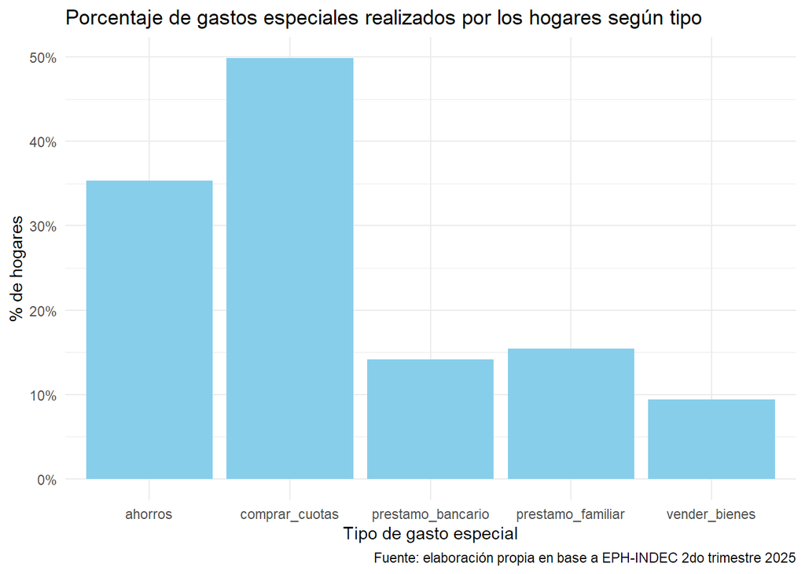

```r
ggplot(data = gastos, aes(x = tipo_gasto, y = prop)) +
  geom_bar(stat = "identity", fill = "skyblue") +
  labs(title = "Porcentaje de gastos especiales realizados por los hogares según tipo",
       caption = "Fuente: elaboración propia en base a EPH-INDEC 2do trimestre 2025",
       x = "Tipo de gasto especial",
       y = "% de hogares") +
  theme_minimal() +
  scale_y_continuous(labels = percent_format())
```

Como las etiquetas de las columnas se pueden solapar entre sí, lo mejor es invertir el eje x y el eje y mediante la función `coord_flip`. Además podemos ordenar las barras en dirección descendente con la función `reorder` en la parte de la estética.

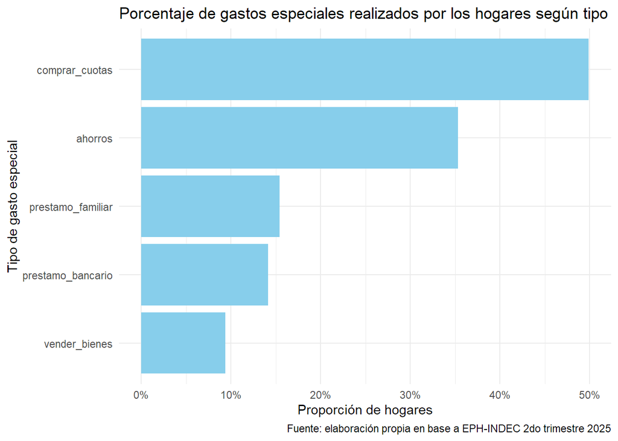

```r
ggplot(data = gastos, aes(x = reorder(tipo_gasto, prop), y = prop)) +
  geom_bar(stat = "identity", fill = "skyblue") +
  labs(title = "Porcentaje de gastos especiales realizados por los hogares según tipo",
       caption = "Fuente: elaboración propia en base a EPH-INDEC 2do trimestre 2025",
       x = "Tipo de gasto especial",
       y = "Proporción de hogares") +
  theme_minimal() +
  scale_y_continuous(labels = percent_format()) +
  coord_flip()
```

Ahora bien, existen otros formatos de gráficos de barras que nos permiten representar un cruce de variables, tal cómo lo hicimos en la clase anterior al elaborar tablas de contingencia. Por ejemplo, podríamos preguntarnos cómo evolucionaron los distintos tipos de gastos por año. Para ello, primero vamos a calcular los porcentajes por año. Luego, vamos a pasar en la capa `aes()` en la opción `fill`, la variable `ANO4`. Al mismo tiempo, en la capa `geom_bar` indicaremos la opción `position = "dodge"`.

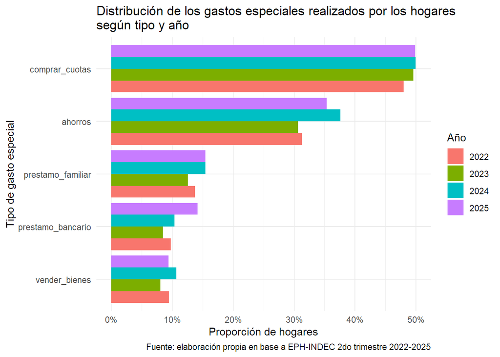

```r
gastos <- eph_hog %>%
  group_by(ANO4) %>%
  summarise(ahorros = sum(PONDERA[ahorros == 1], na.rm = T) / sum(PONDERA, na.rm = T),
            prestamo_familiar = sum(PONDERA[prestamo_familiar == 1], na.rm = T) / sum(PONDERA, na.rm = T),
            prestamo_bancario = sum(PONDERA[prestamo_bancario == 1], na.rm = T) / sum(PONDERA, na.rm = T),
            comprar_cuotas = sum(PONDERA[comprar_cuotas == 1], na.rm = T) / sum(PONDERA, na.rm = T),
            vender_bienes = sum(PONDERA[vender_bienes == 1], na.rm = T) / sum(PONDERA, na.rm = T)) %>%
  pivot_longer(cols = -ANO4,
               names_to = "tipo_gasto",
               values_to = "prop")

gastos %>%
  ggplot(aes(x = reorder(tipo_gasto, prop), y = prop, fill = as.factor(ANO4))) +
  geom_bar(stat = "identity", position = "dodge") +
  labs(title = "Distribución de los gastos especiales realizados por los hogares \nsegún tipo y año",
       caption = "Fuente: elaboración propia en base a EPH-INDEC 2do trimestre 2022-2025",
       x = "Tipo de gasto especial",
       y = "Proporción de hogares",
       fill = "Año") +
  theme_minimal() +
  scale_y_continuous(labels = percent_format()) +
  coord_flip()
```

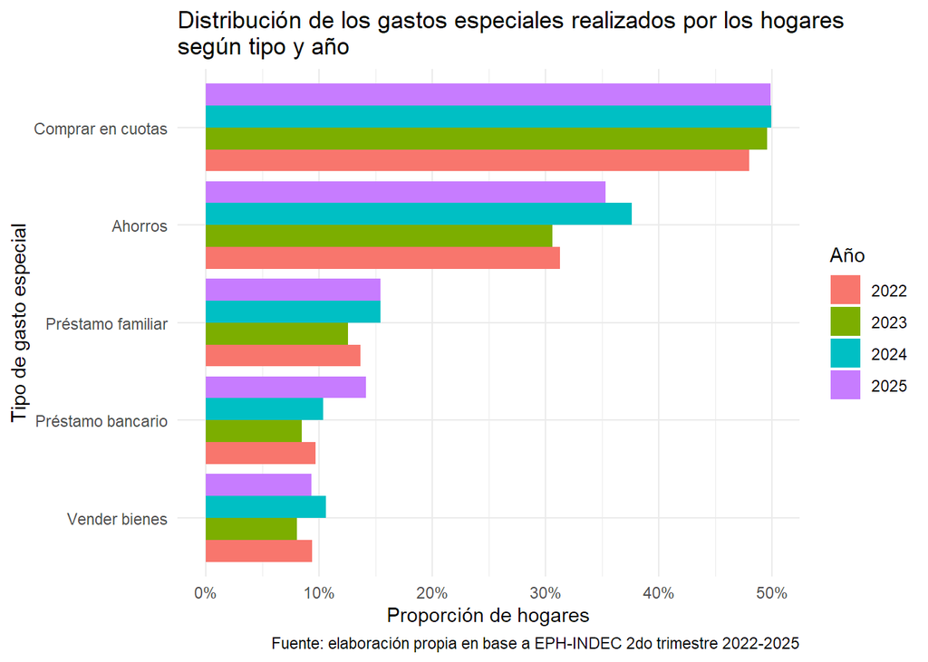

```r
gastos %>%
  ggplot(aes(x = reorder(tipo_gasto, prop), y = prop, fill = as.factor(ANO4))) +
  geom_bar(stat = "identity", position = "dodge") +
  labs(title = "Distribución de los gastos especiales realizados por los hogares \nsegún tipo y año",
       caption = "Fuente: elaboración propia en base a EPH-INDEC 2do trimestre 2022-2025",
       x = "Tipo de gasto especial",
       y = "Proporción de hogares",
       fill = "Año") +
  theme_minimal() +
  scale_y_continuous(labels = percent_format()) +
  scale_x_discrete(labels = c("ahorros" = "Ahorros",
                              "prestamo_familiar" = "Préstamo familiar",
                              "prestamo_bancario" = "Préstamo bancario",
                              "comprar_cuotas" = "Comprar en cuotas",
                              "vender_bienes" = "Vender bienes")) +
  coord_flip()
```

## Referencias

Wickham, Hadley. 2010. «A Layered Grammar of Graphics». *Journal of Computational and Graphical Statistics* 19 (1): 3-28. https://doi.org/10.1198/jcgs.2009.07098.

Wilkinson, Leland. 2005. *The Grammar of Graphics*. 2nd ed. Statistics y Computing. New York: Springer.